# Choosing a car to optimize miles per gallon

Marisa Casillas

# 1 Introduction

Table 1.1: Brands included, along with average number of cylinders and average weight among the number of models included for each brand.

| brand | # Cylinders | Weight | # models |
| --- | --- | --- | --- |
| Datsun | 4.0 | 2.3 | 1 |
| Fiat | 4.0 | 2.1 | 2 |
| Honda | 4.0 | 1.6 | 1 |
| Lotus | 4.0 | 1.5 | 1 |
| Porsche | 4.0 | 2.1 | 1 |
| Toyota | 4.0 | 2.1 | 2 |
| Volvo | 4.0 | 2.8 | 1 |
| Ferrari | 6.0 | 2.8 | 1 |
| Mazda | 6.0 | 2.8 | 2 |
| Valiant | 6.0 | 3.5 | 1 |
| Merc | 6.3 | 3.5 | 7 |
| Hornet | 7.0 | 3.3 | 2 |
| AMC | 8.0 | 3.4 | 1 |
| Cadillac | 8.0 | 5.2 | 1 |
| Camaro | 8.0 | 3.8 | 1 |
| Chrysler | 8.0 | 5.3 | 1 |
| Dodge | 8.0 | 3.5 | 1 |
| Duster | 8.0 | 3.6 | 1 |
| Ford | 8.0 | 3.2 | 1 |
| Lincoln | 8.0 | 5.4 | 1 |
| Maserati | 8.0 | 3.6 | 1 |
| Pontiac | 8.0 | 3.9 | 1 |

We show the unique brands along with their average number of cylinders, average weight, and number of models represented in the dataset in Table 1.1. We summarize our findings in subsection 2 and note that subsection 3.1 is unrelated to this report.

# 2 Results

We modeled mileage with a linear mixed-effects regression, including fixed effects of number of cylinders (numeric), transmission (automatic or manual), and their interaction, as well as a random effect of brand.[^1] Increases in number of cylinders was associated with significant decreases in mileage (*B* = -1.59, *SE* = 0.36, *t* = -4.41). Meanwhile, manual transmissions were associated with significant increases in mileage compared to automatic ones (*B* = 14.11, *SE* = 3.94, *t* = 3.59). That said, the decrease in mileage with more cylinders was significantly greater for manual transmission vehicles than automatic ones (*B* = -1.73, *SE* = 0.68, *t* = -2.55).

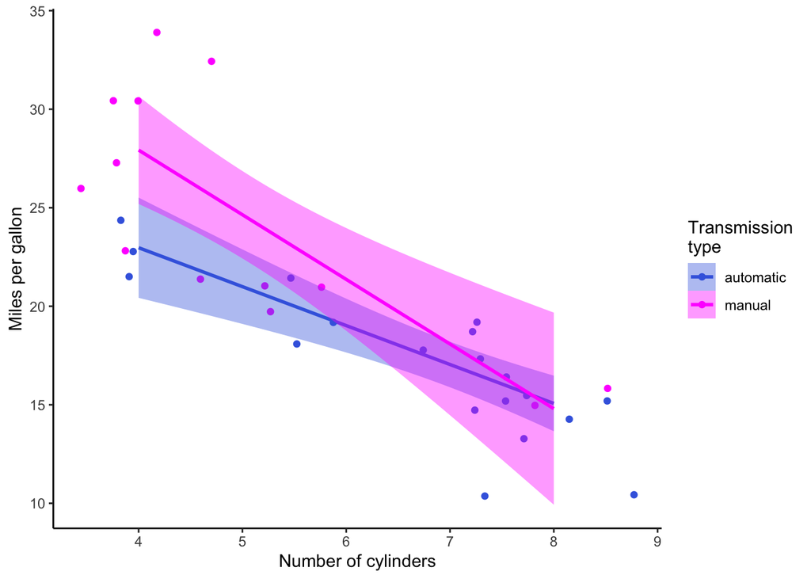

Figure 2.1: Miles per gallon as a function of nunber of cylinders and transmission type in the `mtcars` dataset.

These effects are visualized in Figure 2.1.

# 3 Discussion

In this study we investigated the relationship between miles per gallon, number of cylinders, and transmission type in the `mtcars` dataset. Unsurprisingly, cars with more cylinders and cars with automatic transmissions had lower mileage. The effect of transmission depended on the number of cylinders, such that the mileage benefit associated with manual transmissions decreased for cars with more cylinders. Based on these data, someone trying to maximize their mileage should choose a manual transmission, low-cylinder vehicle.

## 3.1 References we love

You may want to cite references in different formats depending on the surrounding sentential context, e.g.: Casillas, in her (2022) course, states that Rmarkdown is awesome. Rmarkdown is awesome (Casillas, 2021a, 2022; Xie et al., 2018). Rmarkdown is awesome (Casillas, 2022; e.g., Xie et al., 2018). Same-year, same-author publications are automatically disambiguated (e.g., Casillas, 2021a, 2021b). We learned all about ggplot (see Wickham & Grolemund, 2016, ch. 1). We learned about ggplot with Wickham & Grolemund (2016, ch. 1).

This reproducible manuscript is written in Rmarkdown (Xie et al., 2018), using the lme4 (Bates et al., 2015) to run statistical models and ggplot2 (Wickham, 2016) within the tidyverse package (Wickham & Grolemund, 2016) to generate plots.

# 4 References

Bates, D., Mächler, M., Bolker, B., & Walker, S. (2015). Fitting linear mixed-effects models using lme4. *Journal of Statistical Software*, *67*(1), 1–48. https://doi.org/10.18637/jss.v067.i01

Casillas, M. (2021a). *Reproducible science is great*. Various manuscripts.

Casillas, M. (2021b). *What a productive year*. Two publications!!

Casillas, M. (2022). *From Data to Manuscript in R*. UChicago coursework.

Douglas, A., Roos, D., Mancini, F., Couto, A., & Lusseau, D. (2022). *An Introduction to R*. https://intro2r.com/.

Henderson, H. V., & Velleman, P. F. (1981). Building multiple regression models interactively. *Biometrics*, 391–411.

Tierney, N. J. (2020). *RMarkdown for Scientists*. https://rmd4sci.njtierney.com/.

Wickham, H. (2016). *ggplot2: Elegant graphics for data analysis*. Springer-Verlag New York. https://ggplot2.tidyverse.org

Wickham, H., & Grolemund, G. (2016). *R for data science: Import, tidy, transform, visualize, and model data*. O’Reilly Media, Inc.

Xie, Y., Allaire, J. J., & Grolemund, G. (2018). *R markdown: The definitive guide*. Chapman; Hall/CRC.

[^1]: `lmer(mileage ~ cylinders * transmission + (1|brand), data)`